# Effects of Severe Weather Events on Healtha and Economy in the US

Ali Pourkhesalian

12/06/2019

## Synopsis

Storms and other severe weather events can cause both public health and economic problems for communities and municipalities. Many severe events can result in fatalities, injuries, and property damage, and preventing such outcomes to the extent possible is a key concern.

This project involves exploring the U.S. National Oceanic and Atmospheric Administration’s (NOAA) storm database. This database tracks characteristics of major storms and weather events in the United States, including when and where they occur, as well as estimates of any fatalities, injuries, and property damage.

This project, cathegorises all different types of extreme weather conditions (more than 800 different conditions in the original dataset) into main cathegories such as TORNADO, STORM, HAIL, EXTREME COLD etc.

Then the fatalities and injuries caused by each one of the extreme weather condition group is calculated and plotted. Next, the total damage cost caused by each one of the extreme condition group on both properties and crops is calculated and ploted.

## Loading and Processing the Raw Data

### Loading

The data for this assignment come in the form of a comma-separated-value file compressed via the bzip2 algorithm to reduce its size. The file can be downloaded from [here](https://d396qusza40orc.cloudfront.net/repdata%2Fdata%2FStormData.csv.bz2) [47Mb].

```r
    file.url <- 'https://d396qusza40orc.cloudfront.net/repdata%2Fdata%2FStormData.csv.bz2'
#checking if the data exists on the machine
    if (!file.exists('stormdata.bz2')) {download.file(url=file.url, destfile = 'stormdata.bz2')}
#reading data
    storm.data <- read.csv('stormdata.bz2')
```

### Subset

First, out of 37 columns in the dataset, only 7 is needed for the project; so below code subsets the dataset and keeps only those seven required variables.

```r
#subsetting data
    storm.data<- storm.data[c("EVTYPE","FATALITIES","INJURIES","PROPDMG", "PROPDMGEXP","CROPDMG","CROPDMGEXP")]
```

### Processing

Having looked at the dataset, it seems that different names are used for the same extreme weather condinions which makes it very difficult to extract any useful data from it. Ther are 985 extreme condition types which is too many. The below code groups extreme weather conditions that are close to each other into main categories.

```r
    storm.data$EVTYPE<- toupper(storm.data$EVTYPE)
    storm.data$EVENT.TYPE<-
      ifelse(grepl('TORN|GUST|FUNNEL|ROTA', storm.data$EVTYPE), 'TORNADO',
      ifelse(grepl('WINT|ICE|COOL| LOW|COLD|FROST|AVAL|BLIZ|SNOW|FREEZ|FROZ|LOW TEMP|HYPOTH|ICY', storm.data$EVTYPE),'EXTREME WINTER',
      ifelse(grepl('STOR|WIND|HURR|TYPH|TURB|WND', storm.data$EVTYPE), 'STORM',
      ifelse(grepl('DOWNBURST|WATER|FLOO|WET|RAIN|PRECIP|COASTAL|DROWN|TSU|DAM|SHOW|SPOUT|FLD',storm.data$EVTYPE),'FLOOD',
      ifelse(grepl('HAIL',storm.data$EVTYPE),'HAIL',
      ifelse(grepl('HEAT|WARM|HIGH TEMP|HOT|HYPER|TROP',storm.data$EVTYPE),'EXCESS HEAT',
      ifelse(grepl('FIRE|SMOK',storm.data$EVTYPE),'FIRE',
      ifelse(grepl('DRY|DRI|DROUG', storm.data$EVTYPE),'DROUGHT',
      ifelse(grepl('SEA|ROUGH|WAV|MARI|BEACH|RIP|TIDE|CURR|HIGH SEA|SURF|DROW',storm.data$EVTYPE),'SEA AND OCEAN',
      ifelse(grepl('LIGH',storm.data$EVTYPE), 'LIGHTNING',
      ifelse(grepl('VOLC',storm.data$EVTYPE), 'VOLCANO',
      ifelse(grepl('DUS|FOG|VOG',storm.data$EVTYPE ),'FOG&DUST',
      ifelse(grepl('SLI|SWE|LAND', storm.data$EVTYPE),'LAND SLIDE',
      'OTHER')))))))))))))
```

The final 14 main groups are:  
TORNADO, STORM, HAIL, EXTREME WINTER, FLOOD, LIGHTNING, FOG&DUST, SEA AND OCEAN, EXCESS HEAT, OTHER, FIRE, LAND SLIDE, DROUGHT, VOLCANO

#### Fatalities

The below code calculates total number of fatalities from 1950 to November 2011, in the US, based on the even type.

```r
fatalities <- aggregate(FATALITIES~ EVENT.TYPE, storm.data, sum)
```

#### Injuries

The below code calculates total number of injuries from 1950 to November 2011, in the US, based on the even type..

```r
injuries <- aggregate(INJURIES~ EVENT.TYPE, storm.data, sum)
```

#### Economy effects

The below code calculates the total damage cost caused by diffirent types of extreme weather from 1950 to November 2011, in the US.

```r
    #fixing the multiplier in PROPDMGEXP and CROPDMGEXP
    #unique(storm.data$PROPDMGEXP)
    multip.lookup.table <- data.frame(
      symb=unique(as.character(storm.data$PROPDMGEXP)),
      expon=c(3,6,0,9,6,0,0,5,6,0,4,2,3,2,7,2,0,1,8))
    #multip.lookup.table
    storm.data$PROPDMGVAL<-storm.data$PROPDMG*10^multip.lookup.table$expon[match(storm.data$PROPDMGEXP, multip.lookup.table$symb)]
    storm.data$CROPDMGVAL<-storm.data$CROPDMG*10^multip.lookup.table$expon[match(storm.data$CROPDMGEXP, multip.lookup.table$symb)]
    storm.data$TOTALDMGVAL <- storm.data$PROPDMGVAL+storm.data$CROPDMGVAL
    tot.dmg<- aggregate(TOTALDMGVAL~ EVENT.TYPE, storm.data, sum)
```

### Results and Plots

```r
fatalities
```

```
##        EVENT.TYPE FATALITIES
## 1         DROUGHT          3
## 2     EXCESS HEAT       3179
## 3  EXTREME WINTER       1339
## 4            FIRE         90
## 5           FLOOD       1696
## 6        FOG&DUST         82
## 7            HAIL         15
## 8      LAND SLIDE         45
## 9       LIGHTNING        817
## 10          OTHER          9
## 11  SEA AND OCEAN        760
## 12          STORM       1444
## 13        TORNADO       5666
## 14        VOLCANO          0
```

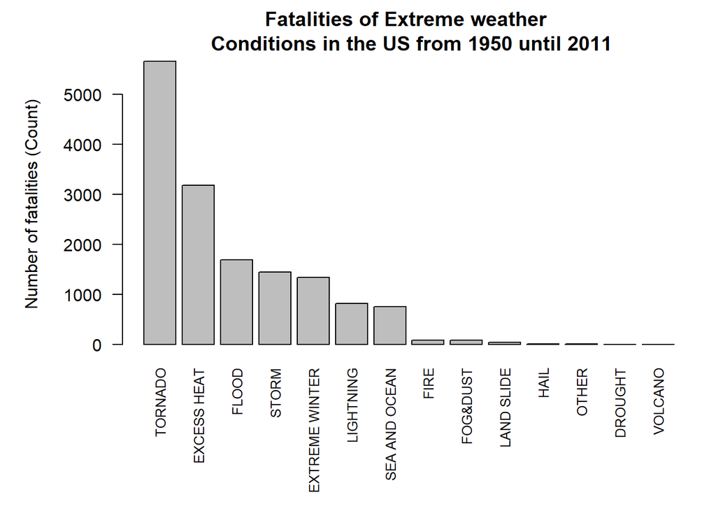

```r
    par(mar=c(8, 6, 3, 1))
    barplot(height = fatalities$FATALITIES[order(fatalities$FATALITIES, decreasing = T)],
            names.arg = fatalities$EVENT.TYPE[order(fatalities$FATALITIES, decreasing = T)],
            las = 2,cex.names = .8,
            ylab = 'Number of fatalities (Count)\n',
            main = 'Fatalities of Extreme weather \n Conditions in the US from 1950 until 2011')
```

#### Injury

```r
injuries
```

```
##        EVENT.TYPE INJURIES
## 1         DROUGHT       32
## 2     EXCESS HEAT     9243
## 3  EXTREME WINTER     6655
## 4            FIRE     1608
## 5           FLOOD     9145
## 6        FOG&DUST     1119
## 7            HAIL     1371
## 8      LAND SLIDE       55
## 9       LIGHTNING     5231
## 10          OTHER      221
## 11  SEA AND OCEAN      797
## 12          STORM    13629
## 13        TORNADO    91422
## 14        VOLCANO        0
```

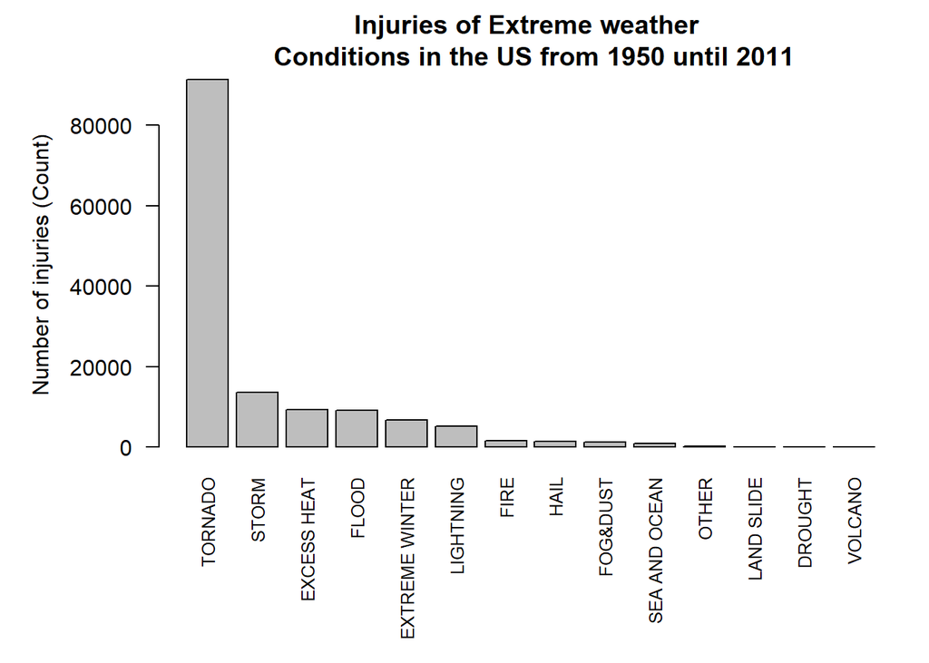

```r
    injuries <- aggregate(INJURIES~ EVENT.TYPE, storm.data, sum)
    par(mar=c(8, 6, 3, 1))
    barplot(height = injuries$INJURIES[order(injuries$INJURIES, decreasing = T)],
            names.arg = injuries$EVENT.TYPE[order(injuries$INJURIES, decreasing = T)],
            las = 2,cex.names = .8,
            ylab = 'Number of injuries (Count)\n',
            main = 'Injuries of Extreme weather \n Conditions in the US from 1950 until 2011')
```

#### Damage cost (in USD)

```r
tot.dmg
```

```
##        EVENT.TYPE  TOTALDMGVAL
## 1         DROUGHT  15025419600
## 2     EXCESS HEAT    926542030
## 3  EXTREME WINTER  21457177611
## 4            FIRE   8905010130
## 5           FLOOD 184859847375
## 6        FOG&DUST     23568130
## 7            HAIL  18782117986
## 8      LAND SLIDE    347433100
## 9       LIGHTNING    942506520
## 10          OTHER      4529950
## 11  SEA AND OCEAN    111228650
## 12          STORM 166919447722
## 13        TORNADO  59022958147
## 14        VOLCANO       500000
```

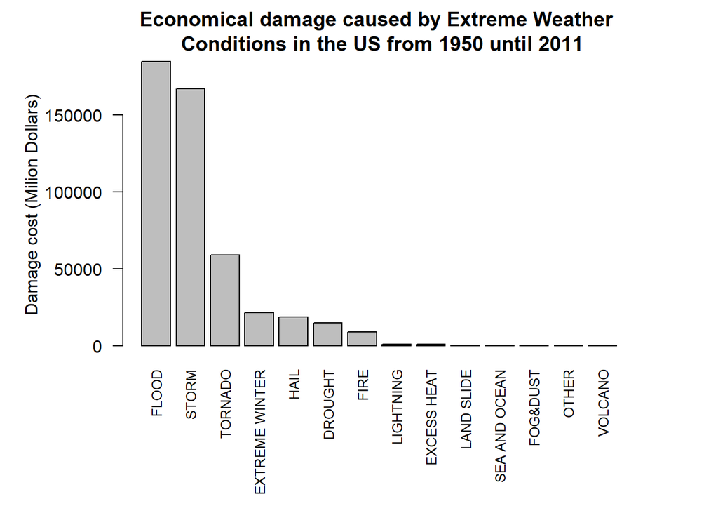

```r
    par(mar=c(8, 6, 3, 4))
    barplot(height = tot.dmg$TOTALDMGVAL[order(tot.dmg$TOTALDMGVAL, decreasing = T)]/10^6,
            names.arg = tot.dmg$EVENT.TYPE[order(tot.dmg$TOTALDMGVAL, decreasing = T)],
            las = 2,cex.names = .8,
            ylab = 'Damage cost (Milion Dollars)\n',
            main = 'Economical damage caused by Extreme Weather \n Conditions in the US from 1950 until 2011')
```